# ESM 244 - Assignment 2

Lydia Bleifuss

2/16/2020

```r
#Helpful Packages
library(tidyverse)
library(janitor)
library(here)
library(skimr)
library(naniar)
library(VIM)
library(ggfortify)
library(lubridate)
library(tsibble)
library(ggthemes)
library(ggplot2)
library(gridExtra)
library(paletteer)

#tsibble
library(tsibble)
library(fable)
library(fabletools)
library(feasts)
library(forecast)
```

### Task 2:

##### 1,2] Introductory Summary and Photos

Steelhead are an important fish within the larger salmonid family that depend on passage up and down the Columbia River Basin to complete its life cycle.

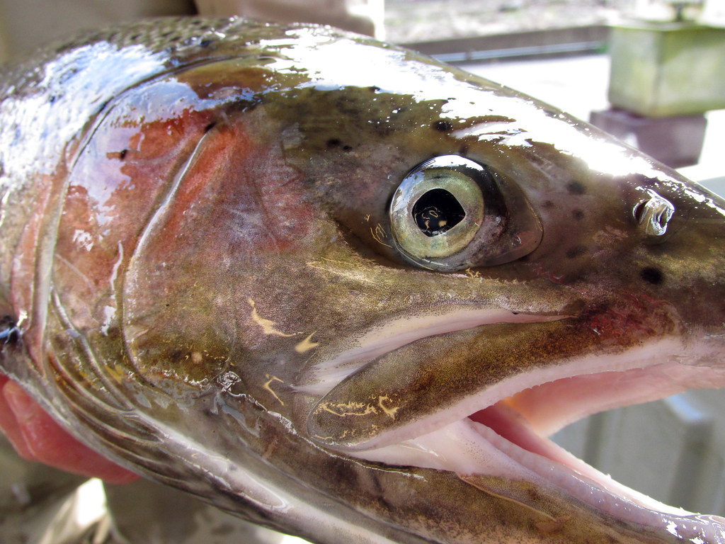

**Steelhead Fish.** Photo: United States Fish and Wildlife Service, Pacific Region

The lower Columbia River has been blocked by large hydroelectric dams since the early 1900’s. Importantly, the lower Columbia and its dynamic waterfalls were once used as historical fishing grounds by the local Native American Tribes, and were also spiritually important for these same groups. With the construction of large dams, both fish populations and cultural heritage were impacted.

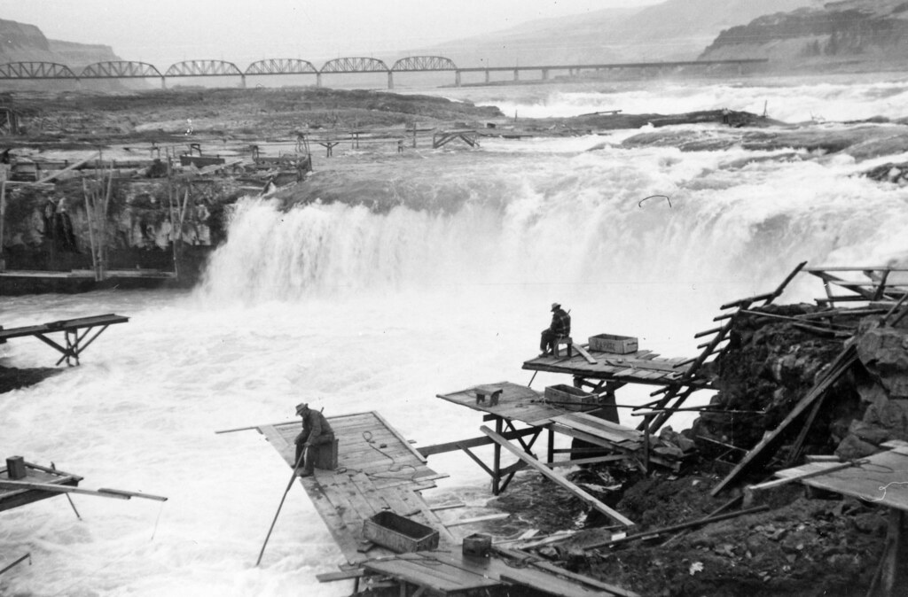

**Celilo Falls - flooded by Dalles Dam, upstream of Bonneville Dam, in 1957.** Photo: Gerald W. Williams Collection

Bonneville Dam was constructed in 1934 and is the first river-wide barrier moving upstream from the Pacific. The amount of salmonid species that surpass the dam successfully, in both directions, is important to understand the health of the species over time, especially as new fish ladder and water quality regulations develop.

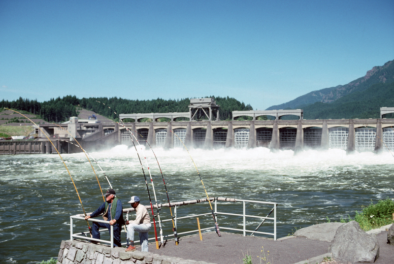

**Bonneville Dam, Columbia River Basin, OR, built in 1934.** Photo: Forest Service

This analysis focuses on Steelhead passage time series data from the Columbia River DART program, although several salmonid species are tracked within this database. In order to understand the health of Steelhead populations, it is important to look at time series data in a variety of ways. The seasonality of Steelhead passage is especially important to consider, as warmer river waters may push passage earlier into the season.

Data from: Columbia Basin Research Available here: Adult fish passage (http://www.cbr.washington.edu/dart/query/adult_graph_text)

Citation: Columbia River DART, Columbia Basin Research, University of Washington. (2019). Adult Passage Graphics & Text. Available from http://www.cbr.washington.edu/dart/query/adult_graph_text